# Research on Startup and Venture Capital Fund

Dung Christian Nguyen

4/1/2020

## INTRODUCTION

This is an analysis of the worldwide venture capital fund allocation. I visualized the data with some plots, mainly using ggplot2.

I drawed a small sample of the 5 market leaders from the data and then carried out some hypothesis testing between the two variables: **funding_total_usd** and **market**

##### First, let’s attach the packages to help generate the graphs

```r
library(tidyverse)
library(ggplot2)
library(scales)
library(rmarkdown)
```

##### Read in data and ommit NA

```r
vc_fund<- read.csv("investments_VC.csv")
vc_Fund <- na.omit(vc_fund)
attach(vc_Fund)
```

##### Top 10 countries of origin

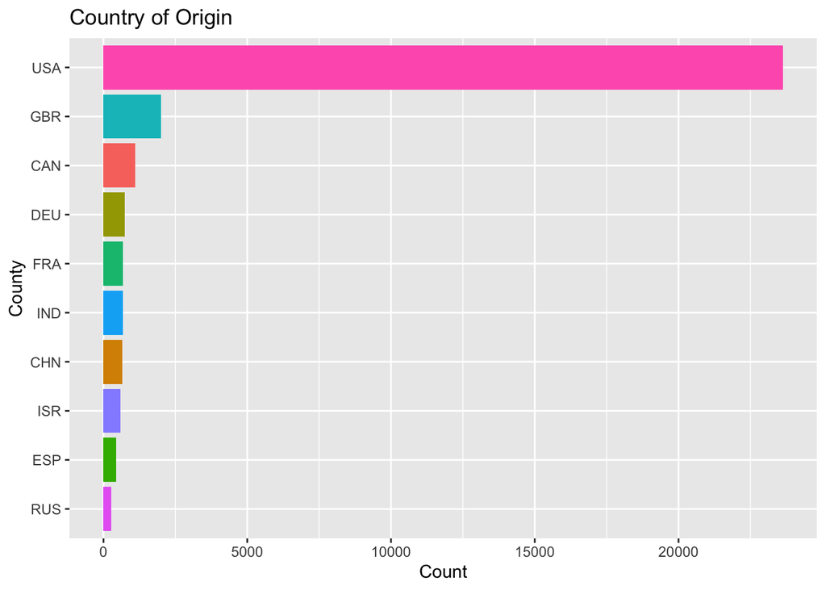

##### Top 10 States Visualization

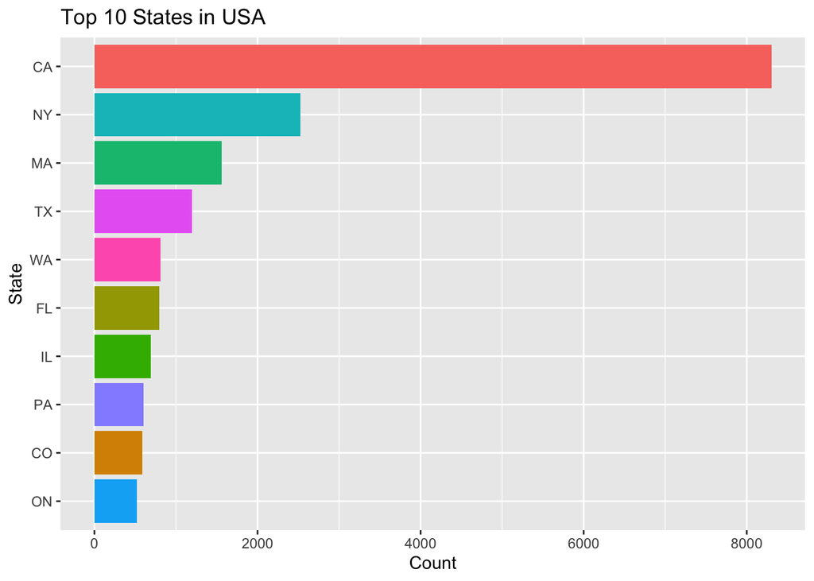

##### Top 10 Region Visualization

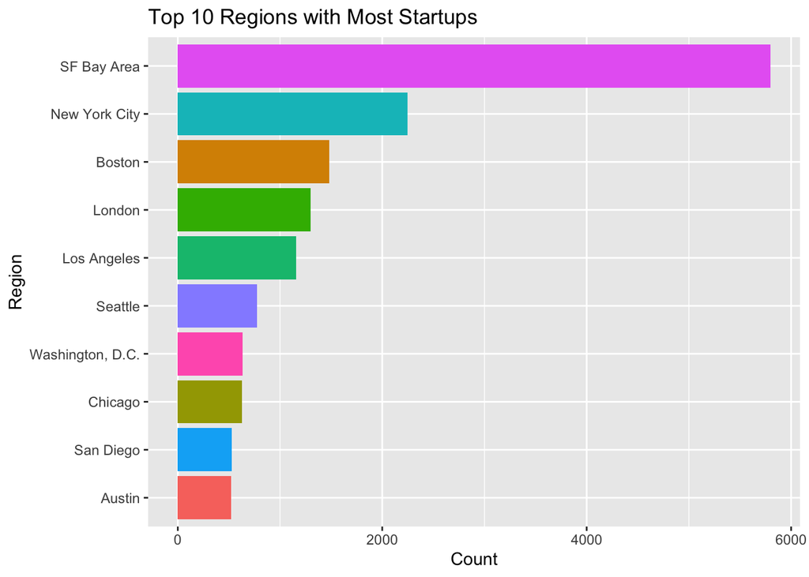

##### Top 10 Market Leaders

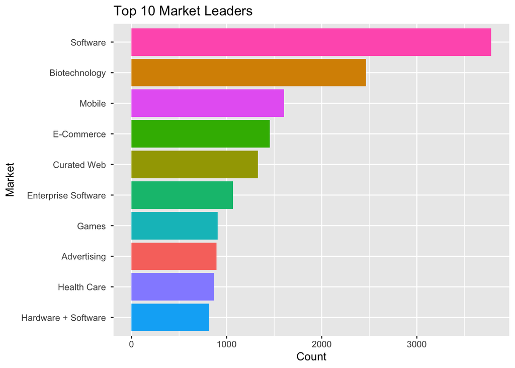

The findings in these chart are not suprising as **the U.S** lead the world in startup count and **San Franciso Bay Area** in particular is the region with the biggest concentration of startup. The most popular market sector is **Software**

##### Founded years (>=2000) visualization

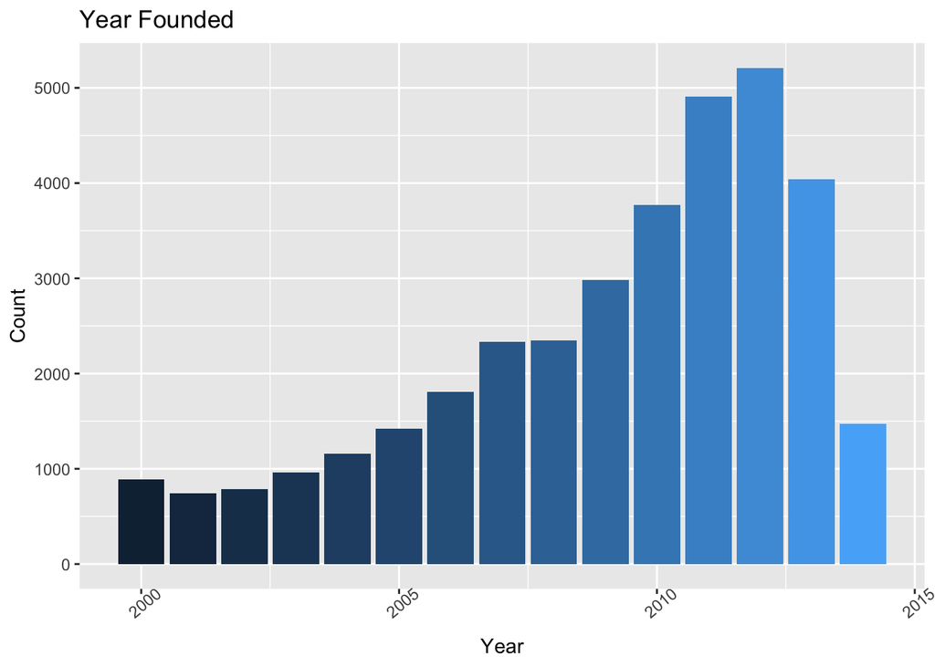

##### Pie Chart of Comapnies’ Status

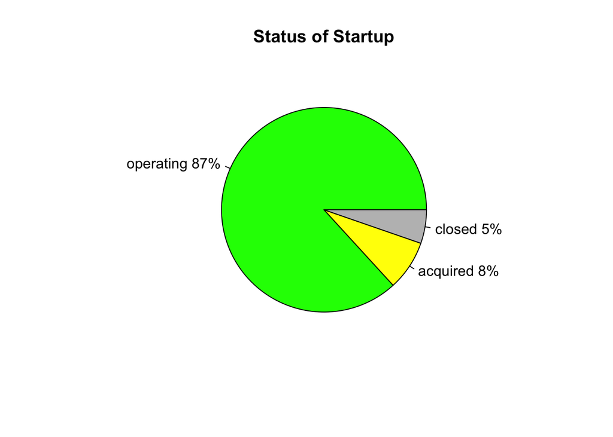

Also, the percentage of successful startup at **95%** (which includes both acquired and operating) are suprisingly **much greater** than the percentage of failed startup.

##### Generate a sample of top 5 leading market leaders and their funding total in USD

```r
detach()
sample_top5_funding_total<- subset(vc_Fund, market ==" Biotechnology " | market ==" Software " |
                            market ==" Mobile "
                          | market==" E-Commerce " | market==" Curated Web ",
                          select=c(market, funding_total_usd))
sample_top5_funding_total2<-subset(sample_top5_funding_total, funding_total_usd!=" NA   ")
sample_top5_funding_total2$funding_total_usd<-as.numeric(gsub(",", "", sample_top5_funding_total2$funding_total_usd))
```

##### ANOVA Testing

H0: mean(software)=mean(mobile)=mean(biotechnology)=mean(curated web)=mean(ecommerce)

H1: at least one of the means is different

```r
total_lm <- lm(funding_total_usd~market, data=sample_top5_funding_total2)
anova(total_lm)
```

```
## Analysis of Variance Table
##
## Response: funding_total_usd
##             Df     Sum Sq    Mean Sq F value Pr(>F)
## market       4 6.5841e+17 1.6460e+17  1.6606 0.1561
## Residuals 9365 9.2830e+20 9.9124e+16
```

The p-value is *0.1561*  
**Decision**: Since the p-value is greater than 0.1, we *fail to reject* the null hypothesis

**Conclusion**: There is no evidence that the mean funding total of the five market leader are different

##### To confirm this finding, we will go ahead and do a pair-wise t test

```r
pairwise.t.test(funding_total_usd, market, "bonferroni")
```

```
##
##  Pairwise comparisons using t tests with pooled SD
##
## data:  funding_total_usd and market
##
##                Biotechnology   Curated Web   E-Commerce   Mobile
##  Curated Web  1.00            -             -            -
##  E-Commerce   1.00            1.00          -            -
##  Mobile       1.00            0.41          1.00         -
##  Software     1.00            1.00          1.00         0.29
##
## P value adjustment method: bonferroni
```

##### Let’s count the number of startups for each market leaders

```r
market_table = sort(table(market), decreasing = TRUE)
head(market_table, n=5)
```

```
## market
##       Software   Biotechnology          Mobile      E-Commerce
##            3327            2373            1402            1175
##    Curated Web
##            1093
```

##### Are the proportions of these different markets the same? Let’s test the hypothesises using Chi-square Goodness-of-fit.

H0: The proportions are the same

H1: The proportions varies and different from each other

```r
top_5_count <- c(3327,2373,1402,1175,1093)
chisq.test(top_5_count, correct = FALSE)
```

```
##
##  Chi-squared test for given probabilities
##
## data:  top_5_count
## X-squared = 1964.5, df = 4, p-value < 2.2e-16
```

**Decision:** Since the p-value is very small, we *reject the null hypothesis*

**Conclusion:** There is strong evidence that the proportion of the each of top 5 market leaders *are not equal*